# fordgobike_exploration

- Bay Wheels Bike Sharing System Usage Pattern (2018) ##### Ahmed Hefnawy

## Investigation_Overview

> [Bay Wheels](https://en.wikipedia.org/wiki/Bay_Wheels)
> - (Ford GoBike previously known) is in the San Francisco Bay Area, California, a regional public cycle sharing scheme. With nearly 500,000 rides since launch in 2017 and about 10,000 annual users as of January 2018, the Bay Wheels is the first regional and large-scale bike sharing system introduced in California and in the West Coast of the United States. The research focused primarily on finding the pattern of usage of bikes and the characteristics of consumer preferences of the 12-month trips data in 2018.

## Dataset_Overview

> The data collection used in this scan consists of [single-monthly journey data] in CSV format for the wider San Francisco Bay area, raw data available From January 2018 to December 2018. Visualisations below are produces with re-drafted and cleaned information to promote scan interpretation and help uncover patterns of usage and trips.

```python
# import tools

import numpy as np
import pandas as pd
import matplotlib.pyplot as plt
import seaborn as sb
import glob
import os
%matplotlib inline
# ------------------------------
```

### Gathering and Assessing Data

```python
# _monthly trip data together

folder_name = 'Data'
frames = [pd.read_csv(f) for f in glob.glob(os.path.join(folder_name, '*.csv'))]
result = pd.concat(frames, ignore_index=True)
print(result.shape)
result.sample(5)
# ------------------------------
```

```
(1863721, 16)
```

|  | duration_sec | start_time | end_time | start_station_id | start_station_name | start_station_latitude | start_station_longitude | end_station_id | end_station_name | end_station_latitude | end_station_longitude | bike_id | user_type | member_birth_year | member_gender | bike_share_for_all_trip |
| --- | --- | --- | --- | --- | --- | --- | --- | --- | --- | --- | --- | --- | --- | --- | --- | --- |
| 205404 | 364 | 2018-08-31 11:08:09.2800 | 2018-08-31 11:14:13.6920 | 9.0 | Broadway at Battery St | 37.798572 | -122.400869 | 23.0 | The Embarcadero at Steuart St | 37.791464 | -122.391034 | 1148 | Subscriber | 1993.0 | Male | No |
| 652974 | 413 | 2018-06-12 07:37:25.6410 | 2018-06-12 07:44:19.1770 | 93.0 | 4th St at Mission Bay Blvd S | 37.770407 | -122.391198 | 130.0 | 22nd St Caltrain Station | 37.757369 | -122.392057 | 2975 | Subscriber | 1981.0 | Male | No |
| 827589 | 1432 | 2018-04-07 12:57:42.3400 | 2018-04-07 13:21:35.0110 | 130.0 | 22nd St Caltrain Station | 37.757369 | -122.392057 | 97.0 | 14th St at Mission St | 37.768265 | -122.420110 | 1634 | Subscriber | 1988.0 | Female | No |
| 348797 | 238 | 2018-08-08 09:06:15.4520 | 2018-08-08 09:10:14.3280 | 211.0 | Broadway at 40th St | 37.827757 | -122.256716 | 176.0 | MacArthur BART Station | 37.828410 | -122.266315 | 1881 | Subscriber | NaN | NaN | No |
| 334957 | 112 | 2018-08-10 07:58:12.0450 | 2018-08-10 08:00:05.0320 | 132.0 | 24th St at Chattanooga St | 37.751819 | -122.426614 | 134.0 | Valencia St at 24th St | 37.752428 | -122.420628 | 651 | Customer | 1987.0 | Female | No |

```python
# __Saving

result.to_csv('fordgobike_trips_2018.csv', index=False)
```

```python
biketrips18 = pd.read_csv('fordgobike_trips_2018.csv')
# ------------------------------
biketrips18.head()
```

|  | duration_sec | start_time | end_time | start_station_id | start_station_name | start_station_latitude | start_station_longitude | end_station_id | end_station_name | end_station_latitude | end_station_longitude | bike_id | user_type | member_birth_year | member_gender | bike_share_for_all_trip |
| --- | --- | --- | --- | --- | --- | --- | --- | --- | --- | --- | --- | --- | --- | --- | --- | --- |
| 0 | 80066 | 2018-10-31 20:49:03.1400 | 2018-11-01 19:03:30.0550 | 138.0 | Jersey St at Church St | 37.750900 | -122.427411 | 147.0 | 29th St at Tiffany Ave | 37.744067 | -122.421472 | 3458 | Customer | 1987.0 | Female | No |
| 1 | 56428 | 2018-10-31 20:18:02.8810 | 2018-11-01 11:58:31.1460 | 75.0 | Market St at Franklin St | 37.773793 | -122.421239 | 86.0 | Market St at Dolores St | 37.769305 | -122.426826 | 1798 | Customer | NaN | NaN | No |
| 2 | 44825 | 2018-10-31 20:07:13.3780 | 2018-11-01 08:34:19.3670 | 139.0 | Garfield Square (25th St at Harrison St) | 37.751017 | -122.411901 | 122.0 | 19th St at Mission St | 37.760299 | -122.418892 | 1575 | Customer | 1983.0 | Female | No |
| 3 | 55461 | 2018-10-31 17:06:37.6830 | 2018-11-01 08:30:59.2200 | 67.0 | San Francisco Caltrain Station 2 (Townsend St... | 37.776639 | -122.395526 | 16.0 | Steuart St at Market St | 37.794130 | -122.394430 | 2978 | Subscriber | 1992.0 | Female | No |
| 4 | 47724 | 2018-10-31 18:27:36.8230 | 2018-11-01 07:43:01.5610 | 259.0 | Addison St at Fourth St | 37.866249 | -122.299371 | 259.0 | Addison St at Fourth St | 37.866249 | -122.299371 | 2392 | Customer | NaN | NaN | No |

```python
# ------------------------------
biketrips18.info()
```

```
<class 'pandas.core.frame.DataFrame'>
RangeIndex: 1863721 entries, 0 to 1863720
Data columns (total 16 columns):
duration_sec               int64
start_time                 object
end_time                   object
start_station_id           float64
start_station_name         object
start_station_latitude     float64
start_station_longitude    float64
end_station_id             float64
end_station_name           object
end_station_latitude       float64
end_station_longitude      float64
bike_id                    int64
user_type                  object
member_birth_year          float64
member_gender              object
bike_share_for_all_trip    object
dtypes: float64(7), int64(2), object(7)
memory usage: 227.5+ MB
```

```python
biketrips18.isnull().sum()
```

```
duration_sec                    0
start_time                      0
end_time                        0
start_station_id            11771
start_station_name          11771
start_station_latitude          0
start_station_longitude         0
end_station_id              11771
end_station_name            11771
end_station_latitude            0
end_station_longitude           0
bike_id                         0
user_type                       0
member_birth_year          110718
member_gender              110367
bike_share_for_all_trip         0
dtype: int64
```

```python
biketrips18.duplicated().sum()
```

```
0
```

```python
biketrips18.member_gender.value_counts()
```

```
Male      1288085
Female     438188
Other       27081
Name: member_gender, dtype: int64
```

```python
biketrips18.user_type.value_counts()
```

```
Subscriber    1583554
Customer       280167
Name: user_type, dtype: int64
```

```python
biketrips18.bike_share_for_all_trip.value_counts()
```

```
No     1701386
Yes     162335
Name: bike_share_for_all_trip, dtype: int64
```

### Cleaning Data

```python
# _make a copy of the dataframe
# ------------------------------
# _Issue>> 1: fix multiple fields that are not in the correct dtype

trips18 = biketrips18.copy()
trips18['start_time'] = pd.to_datetime(trips18['start_time'])
trips18['end_time'] = pd.to_datetime(trips18['end_time'])
# ------------------------------
trips18['start_station_id'] = trips18['start_station_id'].astype('str')
trips18['end_station_id'] = trips18['end_station_id'].astype('str')
trips18['bike_id'] = trips18['bike_id'].astype('str')
# ------------------------------
trips18['user_type'] = trips18['user_type'].astype('category')
trips18['member_gender'] = trips18['member_gender'].astype('category')
# ------------------------------
trips18.info(null_counts=True)
```

```
<class 'pandas.core.frame.DataFrame'>
RangeIndex: 1863721 entries, 0 to 1863720
Data columns (total 16 columns):
duration_sec               1863721 non-null int64
start_time                 1863721 non-null datetime64[ns]
end_time                   1863721 non-null datetime64[ns]
start_station_id           1863721 non-null object
start_station_name         1851950 non-null object
start_station_latitude     1863721 non-null float64
start_station_longitude    1863721 non-null float64
end_station_id             1863721 non-null object
end_station_name           1851950 non-null object
end_station_latitude       1863721 non-null float64
end_station_longitude      1863721 non-null float64
bike_id                    1863721 non-null object
user_type                  1863721 non-null category
member_birth_year          1753003 non-null float64
member_gender              1753354 non-null category
bike_share_for_all_trip    1863721 non-null object
dtypes: category(2), datetime64[ns](2), float64(5), int64(1), object(6)
memory usage: 202.6+ MB
```

```python
# _Issue>> 2: add new columns for trip duration in minute, trip start date in yyyy-mm-dd format, trip start hour of the day, day of week and month

trips18['duration_minute'] = trips18['duration_sec']/60
# ------------------------------
trips18['start_date'] = trips18.start_time.dt.strftime('%Y-%m-%d')
trips18['start_hourofday'] = trips18.start_time.dt.strftime('%H')
trips18['start_dayofweek'] = trips18.start_time.dt.strftime('%A')
trips18['start_month'] = trips18.start_time.dt.strftime('%B')
# ------------------------------
trips18.head()
```

|  | duration_sec | start_time | end_time | start_station_id | start_station_name | start_station_latitude | start_station_longitude | end_station_id | end_station_name | end_station_latitude | ... | bike_id | user_type | member_birth_year | member_gender | bike_share_for_all_trip | duration_minute | start_date | start_hourofday | start_dayofweek | start_month |
| --- | --- | --- | --- | --- | --- | --- | --- | --- | --- | --- | --- | --- | --- | --- | --- | --- | --- | --- | --- | --- | --- |
| 0 | 80066 | 2018-10-31 20:49:03.140 | 2018-11-01 19:03:30.055 | 138.0 | Jersey St at Church St | 37.750900 | -122.427411 | 147.0 | 29th St at Tiffany Ave | 37.744067 | ... | 3458 | Customer | 1987.0 | Female | No | 1334.433333 | 2018-10-31 | 20 | Wednesday | October |
| 1 | 56428 | 2018-10-31 20:18:02.881 | 2018-11-01 11:58:31.146 | 75.0 | Market St at Franklin St | 37.773793 | -122.421239 | 86.0 | Market St at Dolores St | 37.769305 | ... | 1798 | Customer | NaN | NaN | No | 940.466667 | 2018-10-31 | 20 | Wednesday | October |
| 2 | 44825 | 2018-10-31 20:07:13.378 | 2018-11-01 08:34:19.367 | 139.0 | Garfield Square (25th St at Harrison St) | 37.751017 | -122.411901 | 122.0 | 19th St at Mission St | 37.760299 | ... | 1575 | Customer | 1983.0 | Female | No | 747.083333 | 2018-10-31 | 20 | Wednesday | October |
| 3 | 55461 | 2018-10-31 17:06:37.683 | 2018-11-01 08:30:59.220 | 67.0 | San Francisco Caltrain Station 2 (Townsend St... | 37.776639 | -122.395526 | 16.0 | Steuart St at Market St | 37.794130 | ... | 2978 | Subscriber | 1992.0 | Female | No | 924.350000 | 2018-10-31 | 17 | Wednesday | October |
| 4 | 47724 | 2018-10-31 18:27:36.823 | 2018-11-01 07:43:01.561 | 259.0 | Addison St at Fourth St | 37.866249 | -122.299371 | 259.0 | Addison St at Fourth St | 37.866249 | ... | 2392 | Customer | NaN | NaN | No | 795.400000 | 2018-10-31 | 18 | Wednesday | October |

5 rows × 21 columns

```python
# _IIssue>>> 3: add a new column calculating riders' age from 'member_birth_year'

trips18['member_age'] = 2019 - trips18['member_birth_year']
trips18.describe()
# ------------------------------
```

|  | duration_sec | start_station_latitude | start_station_longitude | end_station_latitude | end_station_longitude | member_birth_year | duration_minute | member_age |
| --- | --- | --- | --- | --- | --- | --- | --- | --- |
| count | 1.863721e+06 | 1.863721e+06 | 1.863721e+06 | 1.863721e+06 | 1.863721e+06 | 1.753003e+06 | 1.863721e+06 | 1.753003e+06 |
| mean | 8.573026e+02 | 3.776678e+01 | -1.223492e+02 | 3.776690e+01 | -1.223487e+02 | 1.983088e+03 | 1.428838e+01 | 3.591204e+01 |
| std | 2.370379e+03 | 1.057689e-01 | 1.654634e-01 | 1.056483e-01 | 1.650597e-01 | 1.044289e+01 | 3.950631e+01 | 1.044289e+01 |
| min | 6.100000e+01 | 3.726331e+01 | -1.224737e+02 | 3.726331e+01 | -1.224737e+02 | 1.881000e+03 | 1.016667e+00 | 1.900000e+01 |
| 25% | 3.500000e+02 | 3.777106e+01 | -1.224114e+02 | 3.777106e+01 | -1.224094e+02 | 1.978000e+03 | 5.833333e+00 | 2.800000e+01 |
| 50% | 5.560000e+02 | 3.778107e+01 | -1.223974e+02 | 3.778127e+01 | -1.223971e+02 | 1.985000e+03 | 9.266667e+00 | 3.400000e+01 |
| 75% | 8.720000e+02 | 3.779625e+01 | -1.222865e+02 | 3.779728e+01 | -1.222894e+02 | 1.991000e+03 | 1.453333e+01 | 4.100000e+01 |
| max | 8.636600e+04 | 4.551000e+01 | -7.357000e+01 | 4.551000e+01 | -7.357000e+01 | 2.000000e+03 | 1.439433e+03 | 1.380000e+02 |

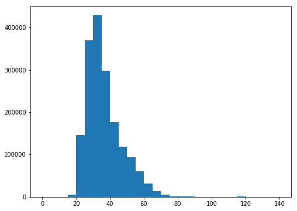

```python
''' _Members' age distribution ,
visually examine for some outliers over 100 yrs old
'''
plt.figure(figsize=[8, 6])
bins = np.arange(0, trips18['member_age'].max()+5, 5)
plt.hist(trips18['member_age'].dropna(), bins=bins);
```

```python
# _Issue>>  4_ filter out outlier ages from visually examination of the distribution above...
# _Issue>> 5_  cast 'member_birth_year' and 'member_age' to integer instead of float type...

trips18 = trips18.query('member_age <= 70')
trips18['member_birth_year'] = trips18['member_birth_year'].astype('int')
trips18['member_age'] = trips18['member_age'].astype('int')
trips18.info(null_counts=True)
```

```
<class 'pandas.core.frame.DataFrame'>
Int64Index: 1745188 entries, 0 to 1863720
Data columns (total 22 columns):
duration_sec               1745188 non-null int64
start_time                 1745188 non-null datetime64[ns]
end_time                   1745188 non-null datetime64[ns]
start_station_id           1745188 non-null object
start_station_name         1733750 non-null object
start_station_latitude     1745188 non-null float64
start_station_longitude    1745188 non-null float64
end_station_id             1745188 non-null object
end_station_name           1733750 non-null object
end_station_latitude       1745188 non-null float64
end_station_longitude      1745188 non-null float64
bike_id                    1745188 non-null object
user_type                  1745188 non-null category
member_birth_year          1745188 non-null int64
member_gender              1745188 non-null category
bike_share_for_all_trip    1745188 non-null object
duration_minute            1745188 non-null float64
start_date                 1745188 non-null object
start_hourofday            1745188 non-null object
start_dayofweek            1745188 non-null object
start_month                1745188 non-null object
member_age                 1745188 non-null int64
dtypes: category(2), datetime64[ns](2), float64(5), int64(3), object(10)
memory usage: 282.9+ MB
```

### What is the structure of your dataset?

The initial composite data comprises about 1.860,000 individual travel documents with 16 compiled variables. Divided into 3 main categories: Variables:

- __trip duration: `duration_sec`, `start_time`, `end_time`
- __station info: `start_station_id`, `start_station_name`, `start_station_latitude`, `start_station_longitude`, `end_station_id`, `end_station_name`, `end_station_latitude`, `end_station_longitude`
- __member info (anonymized): `bike_id`, `user_type`, `member_birth_year`, `member_gender`, `bike_share_for_all_trip`

Derived features/variables to assist exploration and analysis:

- trip info: `duration_minute`, `start_date`, `start_hourofday`, `start_dayofweek`, `start_month`
- __Member: `member_age`

#### **What is/are the main** feature(s) of interest in your _dataset?

I would like much of the time to analyze the length of the bike trips and the rental case trends, along with how those patterns apply to the characteristic features of users, i.e. their type of customer, gender, age, etc. Sample questions: when are more journeys every day, day of the week or month of the year? How much time is the normal journey? Is this contingent on whether a client is a subscriber?

#### __What _features in the dataset do you think will help support your investigation into your feature(s) of interest?

Dates/time and length of a ride allows you to understand how much time and what a trip typically takes. The details given by members such as type of driver, gender or age allows us to figure out which categories of users are the key customers, use the various groups to summarize bike usage data to see if any unique trends are correlated with those riders.

### _Univariate_Exploration

A variety of plots to analyze the distribution of trips during hour of the day, weekday and month.

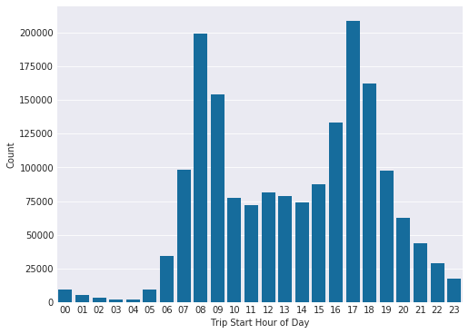

```python
# distribution trip __over day hours............

plt.rcParams['figure.figsize'] = 8, 6
base_color = sb.color_palette('colorblind')[0]
sb.set_style('darkgrid')
#--------------------------------
sb.countplot(data=trips18, x='start_hourofday', color=base_color);
plt.xlabel('Trip Start Hour of Day');
plt.ylabel('Count');
#--------------------------------
```

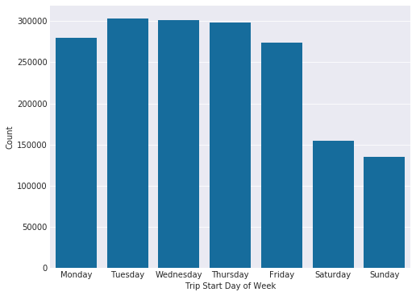

```python
# _distribution over weekdays
# __Issue 6>> cast 'start_dayofweek' to __category__ dtype
weekday = ['Monday', 'Tuesday', 'Wednesday', 'Thursday', 'Friday', 'Saturday', 'Sunday']
weekdaycat = pd.api.types.CategoricalDtype(ordered=True, categories=weekday)
trips18['start_dayofweek'] = trips18['start_dayofweek'].astype(weekdaycat)
#--------------------------------
sb.countplot(data=trips18, x='start_dayofweek', color=base_color);
plt.xlabel('Trip Start Day of Week');
plt.ylabel('Count');
#--------------------------------
```

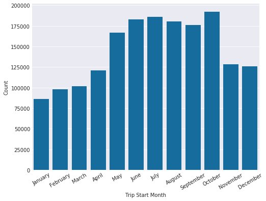

```python
# __distribution over months......
# __Issue 7>>> cast 'start_month' to category dtype for easy plotting
month = ['January', 'February', 'March', 'April', 'May', 'June', 'July', 'August', 'September', 'October', 'November', 'December']
monthcat = pd.api.types.CategoricalDtype(ordered=True, categories=month)
trips18['start_month'] = trips18['start_month'].astype(monthcat)
#--------------------------------
sb.countplot(data=trips18, x='start_month', color=base_color);
plt.xticks(rotation=30);
plt.xlabel('Trip Start Month');
plt.ylabel('Count');
```

The next couple plots will be about users and participants to see what the passengers are.

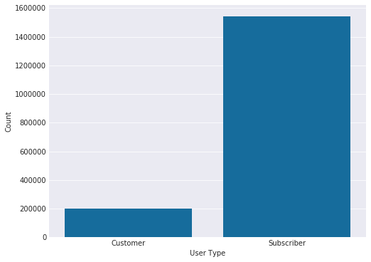

```python
#------------------------------
sb.countplot(data=trips18, x='user_type', color=blue);
#------------------------------
plt.xlabel('User Type');
#------------------------------
plt.ylabel('Count');
#------------------------------
```

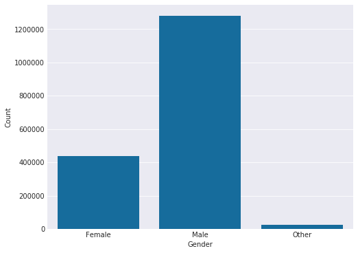

```python
#------------------------------
sb.countplot(data=trips18, x='member_gender', color=blue);
plt.xlabel('Gender');
plt.ylabel('Count');
#------------------------------
```

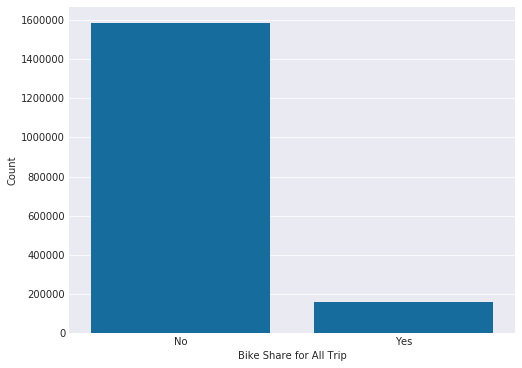

```python
#------------------------------
sb.countplot(data=trips18, x='bike_share_for_all_trip', color=blue);
plt.xlabel('Bike Share for All Trip');
plt.ylabel('Count');
#------------------------------
```

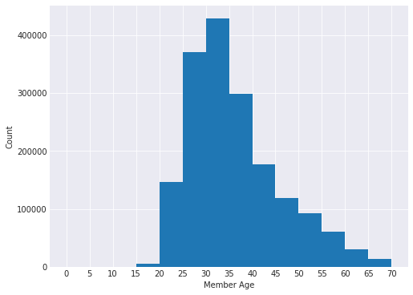

```python
#------------------------------
bins = np.arange(0, trips18['member_age'].max()+5, 5)
plt.hist(data=trips18, x='member_age', bins=bins);
plt.xticks(bins, bins);
plt.xlabel('Member Age');
plt.ylabel('Count');
#------------------------------
```

Many were riders who had no cycle share for both journeys. They were male subscribers. Any of the participants were about 25 and 40 years old. The travel allocation plots were that most trips on Mon-Fri were maxed for one day's rush hours. The age has drastically declined, and the motorcycle use has plummeted.

Distribution of journey length to next story.

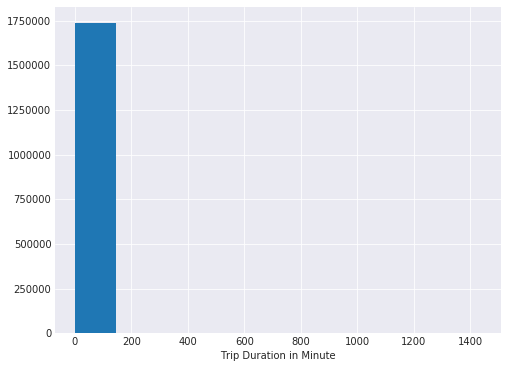

```python
# ----------------------
plt.hist(data=trips18, x='duration_minute');
plt.xlabel('Trip Duration in Minute');
# ----------------------
```

It was a little shocking to see the length range stretch very far to the right (indicates a long rental time, almost 24 hours) (within 200 mins). To zoom into a closer view of the distribution in the majority of situations.

```python
# ---------------------------
trips18['duration_minute'].describe(percentiles=[.99])
```

```
count    1.745188e+06
mean     1.296786e+01
std      3.311037e+01
min      1.016667e+00
50%      9.050000e+00
99%      6.525000e+01
max      1.438017e+03
Name: duration_minute, dtype: float64
```

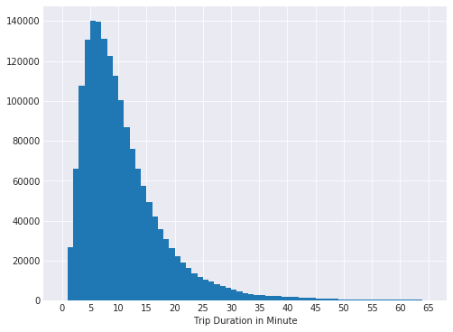

```python
# ---------------------------
bins = np.arange(0, 66, 1)
ticks = np.arange(0, 66, 5)
# ---------------------------
plt.hist(data=trips18, x='duration_minute', bins=bins);
plt.xticks(ticks, ticks);
plt.xlabel('Trip Duration in Minute');
# ---------------------------
```

It looks like 99% of the trips were less than 1 hour long with most of them fell between 5 to 10 minutes range. I'll remove the outlier long trips for this study to allow focusing on the most common cases to explore the pattern.

```python
# __Issue 8>> _filter out outlier trip records where the duration was very long..

trips18 = trips18.query('duration_minute <= 66')
trips18.info(null_counts=True)
# ---------------------------
```

```
<class 'pandas.core.frame.DataFrame'>
Int64Index: 1727985 entries, 7 to 1863720
Data columns (total 22 columns):
duration_sec               1727985 non-null int64
start_time                 1727985 non-null datetime64[ns]
end_time                   1727985 non-null datetime64[ns]
start_station_id           1727985 non-null object
start_station_name         1716963 non-null object
start_station_latitude     1727985 non-null float64
start_station_longitude    1727985 non-null float64
end_station_id             1727985 non-null object
end_station_name           1716963 non-null object
end_station_latitude       1727985 non-null float64
end_station_longitude      1727985 non-null float64
bike_id                    1727985 non-null object
user_type                  1727985 non-null category
member_birth_year          1727985 non-null int64
member_gender              1727985 non-null category
bike_share_for_all_trip    1727985 non-null object
duration_minute            1727985 non-null float64
start_date                 1727985 non-null object
start_hourofday            1727985 non-null object
start_dayofweek            1727985 non-null category
start_month                1727985 non-null category
member_age                 1727985 non-null int64
dtypes: category(4), datetime64[ns](2), float64(5), int64(3), object(8)
memory usage: 257.1+ MB
```

### _Discuss the distribution(s) of your variable(s) of interest. Were there any unusual points? Did you need to perform any transformations?

During a day there were more trips on work days (Monday - Fri) than at weekends, which peaked around 8-9 am and 17-18 pm. The overview duration was presumably because of the weather the most common season of a year.

Most cycling was quick and easy. It took about 5 to 10 minutes, but very long outliers, such as 24 hours, were found.

Fortunately, due to the nature of the results, no transformation was necessary.

### Of the features you investigated, were there any unusual distributions? Did you perform any operations on the data to tidy, adjust, or change the form of the data? If so, why did you do this?

When the initial data were first plotted the distribution of the tour length was a little shocking. Using.describe() and xticks(), the distribution was much simpler in a narrower range where more reports of trip fell. I have filtered the outlier long travel records for the sample with .quest in order to better concentrate on the key cases of standard machine use ().

```python
# __Save the clean data to a .csv file.............
# ------------------------
trips18.to_csv('fordgobike_trips_2018_clean.csv', index=False)
```

### _Bivariate__Exploration

How does the trip duration distribution vary between customers and subscribers?

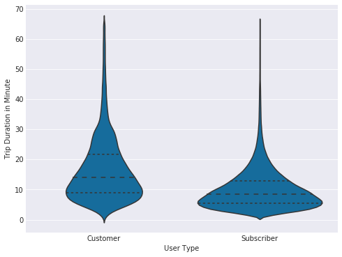

```python
# ========================
sb.violinplot(data=trips18, x='user_type', y='duration_minute', color=base_color, inner='quartile');
plt.xlabel('User Type');
plt.ylabel('Trip Duration in Minute');
# ========================
```

In contrast to casual drivers on the shorter / faster route, the allocation of the journey length is much less for subscribers. It seems that subscribers are using the bikes more precisely or have a particular target in contrast to clients who differ more and normally hire the bikes longer in general.

How does the trip duration distribution vary by gender?

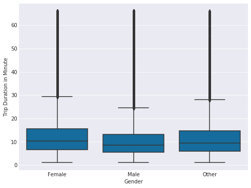

```python
# -------------------------------
sb.boxplot(data=trips18, x='member_gender', y='duration_minute', color=base_color);
plt.xlabel('Gender');
plt.ylabel('Trip Duration in Minute');
# -------------------------------
```

Although not a major gap, men appear to fly shorter than women, both a median and a shorter IQR suggest.

__Average Trip Duration on Weekdays

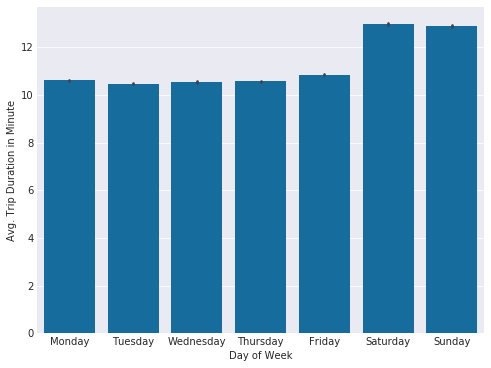

```python
# --------*******************
sb.barplot(data=trips18, x='start_dayofweek', y='duration_minute', color=base_color);
plt.xlabel('Day of Week');
plt.ylabel('Avg. Trip Duration in Minute');
# --------*******************
```

On Monday through Friday, cycling journeys are much shorter than on weekends. In normally operating days, it means that the device is used very stably and efficiently and on weekends more casually versatile.

Average trip duration by month

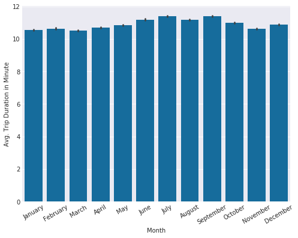

```python
# ==========================
sb.barplot(data=trips18, x='start_month', y='duration_minute', color=base_color);
plt.xticks(rotation=30);
plt.xlabel('Month');
plt.ylabel('Avg. Trip Duration in Minute');
# ==========================
```

Member age by weekdays

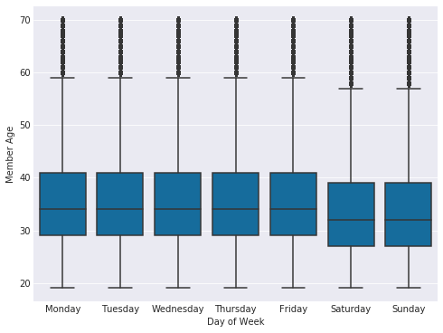

```python
# --------------------------------
sb.boxplot(data=trips18, x='start_dayofweek', y='member_age', color=base_color);
plt.xlabel('Day of Week');
plt.ylabel('Member Age');
# --------------------------------
```

Riders who leased bikes from Monday to Friday are somewhat older than the ones who travel on weekends, which is the commute to work observed from the previous uniform plots.

Weekly usage between customers and subscribers

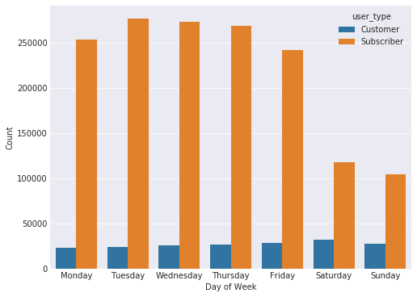

```python
# ============================
sb.countplot(data=trips18, x='start_dayofweek', hue='user_type');
plt.xlabel('Day of Week');
plt.ylabel('Count');
# ============================`
```

There was a lot more use of subscribers than casual clients in general. The decline in weeks for subscribers means they ride mostly bikes for the workdays, while almost the other way around a small rise in customer use at weekends shows that the use is more tailored to leisure/touring and recreation purposes.

Daily usage between customers and subscribers

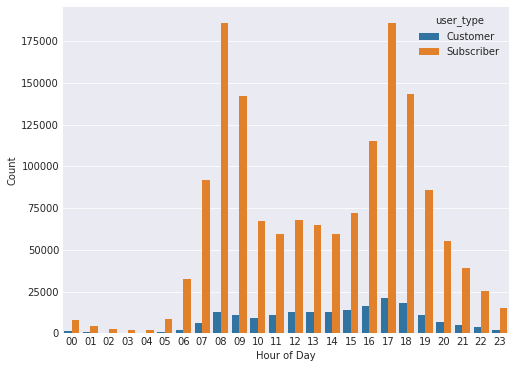

```python
# ------------------------------
sb.countplot(data=trips18, x='start_hourofday', hue='user_type');
plt.xlabel('Hour of Day');
plt.ylabel('Count');
# ------------------------------
```

When the people go to work in the early morning and leave work in the afternoon, subscriber use obviously reached its height at the standard hour when the aim and intent of riding have been proven by double. Similar trends were not found among customers who most prefer to drive for a reason other than their subscriber drivers during the afternoon or early evenings.

Yearly usage between customers and subscribers

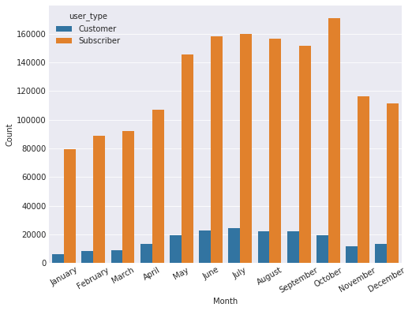

```python
# -------------------------------
sb.countplot(data=trips18, x='start_month', hue='user_type');
plt.xticks(rotation=30);
plt.xlabel('Month');
plt.ylabel('Count');
# -------------------------------
```

Subscribers and consumers more often fly with subscribers in October and customers in July. The winter season as November, December and January was obviously not common as a result of weather conditions.

Member age between customers and subscribers

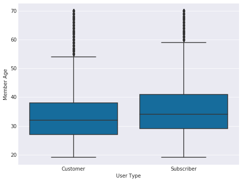

```python
#-------------------------------
sb.boxplot(data=trips18, x='user_type', y='member_age', color=base_color);
plt.xlabel('User Type');
plt.ylabel('Member Age');
#-------------------------------
```

Like user age per weekday, members who fly more regularly between Monday and Friday are more older than customers and have a broader range of ages.

#### __Talk about some of the relationships you observed in this part of the investigation. How did the feature(s) of interest vary with other features in the dataset?

There is a lot more use than consumers for subscribers. There is a lot of disparity in consumer and client riding practices / trends. Subscribers use the bike sharing scheme to cycle on a work-place basis. This means that most tours have been on workdays (Mondays-Fri) and particularly in peak hours (e.g. when you work in the mornings and get off work in the afternoons). The user of subscriber are slightly older than the user who, particularly during the summer, tends to take longer drives.

### Did you observe any interesting relationships between the other features (not the main feature(s) of interest)?

Interestingly, subscribers are a little older than customers, but take far shorter and faster journeys than usual. And October has become the year-round most used cycling by subscribers.

## _Multivariate_Exploration

How does the average trip duration vary in weekdays between customers and subscribers?

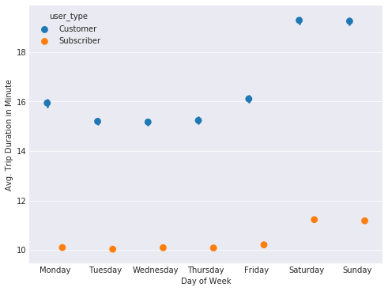

```python
sb.pointplot(data=trips18, x='start_dayofweek', y='duration_minute', hue='user_type', dodge=0.3, linestyles="");
plt.xlabel('Day of Week');
plt.ylabel('Avg. Trip Duration in Minute');
```

It can be seen from the above plot that subscribers ride much shorter/quicker trips compared to customers on each day of the week. Both user types have an obvious increase of trip duration on Saturdays and Sundays over weekends, especially for casual riders. Subscribers usage seems to be more efficient than customers overall and maintained a very consistent average duration Monday through Friday.

How does the hourly usage vary during weekdays for customers and subscribers?

[figure not shown]

```python
plt.suptitle('_Hourly Usage during Weekdays >>  _Customers & _Subscribers')
# ---------------------------------
plt.subplot(2, 1, 1)
customers = trips18.query('user_type == "Customer"')
ct_counts = customers.groupby(['start_dayofweek', 'start_hourofday']).size()
ct_counts = ct_counts.reset_index(name='count')
ct_counts = ct_counts.pivot(index='start_dayofweek', columns='start_hourofday', values='count')
sb.heatmap(ct_counts, cmap='rocket_r');
plt.title('Customer', loc='right');
plt.xlabel('Hour of Day');
plt.ylabel('Day of Week');
# ---------------------------------
plt.subplot(2, 1, 2)
subscribers = trips18.query('user_type == "Subscriber"')
st_counts = subscribers.groupby(['start_dayofweek', 'start_hourofday']).size()
st_counts = st_counts.reset_index(name='count')
st_counts = st_counts.pivot(index='start_dayofweek', columns='start_hourofday', values='count')
sb.heatmap(st_counts, cmap='rocket_r');
plt.title('Subscriber', loc='right');
plt.xlabel('Hour of Day');
plt.ylabel('Day of Week');
```

It shows clear that the pattern/custom of use between the two groups of riders is quite different. The machine is used extensively by subscribers on business days that entails. Customers drive a lot on weekends, particularly afternoon from Monday to Friday. Often tours focused on working days for subscribers during work traffic around 8-9am and 17-18pm, but consumers prefer to use more at around 17pm on late afternoons from Monday to Friday. It may also contribute to the traffic situation during certain peak hours in the city rather than the intent of use and tradition.

#### Talk about some of the relationships you observed in this part of the investigation. Were there features that strengthened each other in terms of looking at your feature(s) of interest?

Multivariate analysis confirmed some of the trends discovered in the previous bivariate study, as well as the univariate exploration, visualized the relationship between the different variables plotted and combined knowledge. For subscribers, the efficient/short use duration reflects their high rush hours from Monday until Friday, suggesting that their use is mostly for working routes. The calming and versatile trend of user use indicates that the bike share scheme is taken advantage of very differently from the customers, perhaps for city or entertainment purposes on most weekends and in the afternoon.

#### Were there any interesting or surprising interactions between features?

Both function interactions compliment each other. When combined, there is no great surprise. The interactions are very meaningful. The disparity in the habit between men and women during the discovery is not so obvious or obvious, which may have to do with the imbalanced number of riders/racords compared with men. If more feminine data exist, it would be fascinating to see how men and women use the system differently.